# xGEMS tutorial 1 — basics for a hydrothermal geochemist

**Chemical system:** MORB-type basalt glass + seawater, initialised from `gems_files/SW-B_titr3-dat.lst`.

This notebook walks through the everyday `xgems` functionality using the **dictionary interface** (`ChemicalEngineDicts`) and the **`Material`** helper for building recipes. It mirrors the structure of the official [`gemshub/xgems-jupyter`](https://github.com/gemshub/xgems-jupyter) `basics_xgems.ipynb` and the `Material` demo, but is themed around water–rock interaction.

**Contents**

1. Initialise, re-equilibrate, return codes, print
2. Extract data from the equilibrium state
3. Set a new composition / T / P and equilibrate (granite + saline water)
4. Build a `Material` — basalt glass (element moles · oxide masses · oxide moles)
5. Build a `Material` — seawater (1 kg H₂O + dissolved major ions)
6. Suppress the Brucite and Dolomite phases (metastability limit = 0) and re-check SI
7. Add CO₂ and read the gas fugacity
8. Hydrothermal extras: T–P saturation sweep · Eh–pH · aqueous speciation

## 0. Imports

`ChemicalEngineDicts` is the name-keyed interface: every getter returns a Python `dict` keyed by element / species / phase name (no index bookkeeping). `Material` turns human recipes (formulas, grams, oxides) into the bulk-composition vector **b** that GEM minimisation needs.

```python
import numpy as np
import pandas as pd
import matplotlib.pyplot as plt

from xgems import ChemicalEngineDicts, Material

# Path to your GEM-Selektor standalone export. Everything downstream keys off this.
LST = "gems_files/SW-B_titr3-dat.lst"
```

## 1. Initialise, re-equilibrate, return codes, print

`ChemicalEngineDicts(LST)` loads the chemical system (elements, species, phases, thermodynamic data and activity models) exactly as defined in GEM-Selektor. `reequilibrate()` recomputes the Gibbs-energy-minimum state.

**GEMS return / calculation codes** (returned as a short string here):

| mode | meaning |
| --- | --- |
| warm start | SIA — smart initial approximation, reuses the previous speciation |
| cold start | AIA — automatic (LPP) initial approximation from scratch |

`0` no recalculation needed · `1` need AIA · `2` OK after AIA · `3` suspect after AIA · `4` AIA failure · `5` need SIA · `6` OK after SIA · `7` suspect after SIA · `8` SIA failure · `9` terminal GEMS3K error (restart required). A trustworthy result is **2** (cold) or **6** (warm).

```python
gems = ChemicalEngineDicts(LST)

status = gems.reequilibrate()          # warm start by default
print("re-equilibration status:", status)

# NOTE on API style: in ChemicalEngineDicts the *output getters* (pH, phase_names,
# phases_volume, phase_sat_indices, ...) are exposed as ATTRIBUTES (no parentheses).
# Actions/setters (equilibrate, set_bulk_composition, suppress_phase, ...) are called
# with (). If a getter raises "method not callable" style errors,
# simply add () to it.
print("pH             :", gems.pH)
print("Eh (V)         :", gems.Eh)
print("ionic strength :", gems.ionic_strength, "mol/kg")
print("system mass    :", gems.system_mass, "kg")
print("system volume  :", gems.system_volume, "m3")
```

```
re-equilibration status: OK after GEM calculation with LPP AIA
pH             : 5.736364839778835
Eh (V)         : -0.24873784250742578
ionic strength : 0.48436210410104147 mol/kg
system mass    : 1.0500000000000005 kg
system volume  : 0.0011198598456421051 m3
```

A full human-readable dump of the state is handy for eyeballing or for pasting into an LLM to ask questions about the result:

```python
with open("result_initial.txt", "w") as f:
    f.write(repr(gems))          # same content as GEM-Selektor's multi-page print
print("wrote result_initial.txt")
```

```
wrote result_initial.txt
```

## 2. Extract data from the equilibrium state

Because getters are name-keyed dicts, pulling results into a `pandas` table is trivial. Below: a phase-level summary (amount, mass, volume, saturation index) and the aqueous molalities of the elements.

```python
# --- phase-level summary -------------------------------------------------
phase_df = pd.DataFrame({
    "moles"      : gems.phases_moles,
    "mass_kg"    : gems.phases_mass,
    "volume_m3"  : gems.phases_volume,
    "vol_frac"   : gems.phases_volume_frac,
    "SI"         : gems.phase_sat_indices,     # log10(IAP/K): 0 = at equilibrium
}).sort_values("mass_kg", ascending=False)

# "present" phases = those with a non-trivial amount
present = phase_df[phase_df["moles"] > 1e-12]
present
```

|  | moles | mass_kg | volume_m3 | vol_frac | SI |
| --- | --- | --- | --- | --- | --- |
| aq_gen | 5.436601e+01 | 9.953180e-01 | 1.100924e-03 | 9.830906e-01 | -1.515020e-10 |
| Chlorite | 3.756845e-02 | 2.215843e-02 | 7.959969e-06 | 7.108004e-03 | 9.726927e-07 |
| Cpx | 4.337873e-02 | 1.034990e-02 | 2.932292e-06 | 2.618446e-03 | -4.949874e-08 |
| Plagioclase | 3.133488e-02 | 8.227196e-03 | 3.155728e-06 | 2.817967e-03 | 3.944477e-08 |
| Alkali Feldspar | 3.133488e-02 | 8.227196e-03 | 3.155728e-06 | 2.817967e-03 | 3.944477e-08 |
| Anhydrite | 2.326920e-02 | 3.167929e-03 | 1.070616e-06 | 9.560264e-04 | 1.555472e-08 |
| Titanite | 8.116808e-03 | 1.591223e-03 | 4.534161e-07 | 4.048864e-04 | 5.924828e-13 |
| Epidote | 1.051693e-03 | 5.087928e-04 | 1.470592e-07 | 1.313193e-04 | 3.288575e-08 |
| Galena | 1.685005e-03 | 4.031661e-04 | 5.306081e-08 | 4.738165e-05 | -3.187353e-08 |
| Chalcocite | 3.024765e-04 | 4.814186e-05 | 8.312053e-09 | 7.422405e-06 | 9.024078e-08 |
| Gold | 1.973542e-07 | 3.887227e-08 | 2.015974e-12 | 1.800202e-09 | 1.295638e-08 |

```python
# --- aqueous chemistry ---------------------------------------------------
aq = pd.DataFrame({
    "molality_mol_per_kgH2O": gems.aq_elements_molality,
    "molarity_mol_per_L"    : gems.aq_elements_molarity
})
aq["log10_molality"] = np.log10(aq["molality_mol_per_kgH2O"].where(lambda s: s > 0))
aq.sort_values("molality_mol_per_kgH2O", ascending=False)
```

|  | molality_mol_per_kgH2O | molarity_mol_per_L | log10_molality |
| --- | --- | --- | --- |
| H | 1.110173e+02 | 9.702800e+01 | 2.045391 |
| O | 5.554341e+01 | 4.854439e+01 | 1.744633 |
| Cl | 5.682311e-01 | 4.966284e-01 | -0.245475 |
| Na | 4.543568e-01 | 3.971034e-01 | -0.342603 |
| Ca | 4.649827e-02 | 4.063903e-02 | -1.332563 |
| K | 1.394067e-02 | 1.218401e-02 | -1.855716 |
| Si | 9.013460e-03 | 7.877675e-03 | -2.045108 |
| Zn | 6.451293e-03 | 5.638366e-03 | -2.190353 |
| S | 3.096954e-03 | 2.706707e-03 | -2.509065 |
| C | 2.043618e-03 | 1.786102e-03 | -2.689600 |
| Pb | 2.844372e-04 | 2.485953e-04 | -3.546014 |
| Mg | 8.236342e-05 | 7.198481e-05 | -4.084266 |
| Cu | 3.502738e-05 | 3.061358e-05 | -4.455592 |
| Al | 2.334644e-06 | 2.040456e-06 | -5.631779 |
| Ag | 3.910193e-07 | 3.417470e-07 | -6.407802 |
| Fe | 2.441037e-07 | 2.133442e-07 | -6.612426 |
| Au | 9.032116e-09 | 7.893980e-09 | -8.044210 |
| Ti | 1.822834e-09 | 1.593139e-09 | -8.739253 |
| Zz | -3.493782e-17 | -3.053531e-17 | NaN |

```python
# The full system recipe (b vector) as a dict — the master input to GEM:
b0 = gems.bulk_composition          # {element: moles}
print(b0)
```

[output not shown]

## 3. Set a new composition / material / T / P and equilibrate

Rather than reusing the exported recipe, we build a fresh system from two `Material`s — a **leucogranite** (four rock-forming minerals, by mass) and a **saline water** (1 kg H₂O + 30 g NaCl) — add them together, and equilibrate. Two equivalent routes are shown:

- **stateful** — set `T`, `P`, then `set_bulk_composition(b)` and call `equilibrate()`;
- **one-shot** — `equilibrate(T, P, recipe)`.

`T` is in **kelvin**, `P` in **pascal**. We run at 100 °C / 50 bar and dump the resulting state to `result_granite.txt`.

```python
granite = Material(gems, "leucogranite")
granite.add("KAlSi3O8",        17.0, "g")    # Microcline
granite.add("KAl3Si3O10(OH)2", 19.0, "g")    # Muscovite
granite.add("NaAlSi3O8",       29.0, "g")    # Albite
granite.add("SiO2",            35.0, "g")    # Quartz
```

```
Material('leucogranite', 4 constituents, 100 g, 0.801888 mol)
```

```python
water = Material(gems, "water")
water.add("H2O", 1000.0, "g")
water.add("NaCl", 30, "g")    # 30 g NaCl in ~1 kg water (a saline solution)
```

```
Material('water', 2 constituents, 1030 g, 56.0217 mol)
```

```python
T = 100.0 + 273.15      # K
P = 50e5                # Pa  (50 bar)

mix = granite+water

# --- stateful route ---
gems.T = T
gems.P = P
gems.set_bulk_composition(mix.b_dict())
status = gems.equilibrate()
print("stateful  ->", status, "| pH", round(gems.pH, 3))

# --- one-shot route (identical result) ---
status = gems.equilibrate(T, P, mix)
print("one-shot  ->", status, "| pH", round(gems.pH, 3))
```

```
stateful  -> OK after GEM calculation with LPP AIA | pH 6.684
one-shot  -> OK after GEM calculation with LPP AIA | pH 6.684
```

```python
with open("result_granite.txt", "w") as f:
    f.write(repr(gems))          # same content as GEM-Selektor's multi-page print
print("wrote result_granite.txt")
```

```
wrote result_granite.txt
```

## 4. Build a `Material` — basalt glass

A `Material` converts a recipe into the bulk-composition vector **b**. Here the same basalt glass is expressed three equivalent ways, to show the flexibility of `Material`:

1. **element moles** — total iron lumped as ferrous (`Fe`), scaled to 100 g;
2. **oxide blend by mass** — grams of each oxide (with `FeO` and `Fe₂O₃` listed separately);
3. **oxide blend by moles** — moles per formula unit (the version carried downstream as `basalt`).

**Iron.** This chemical system tracks *total* iron through a single `Fe` component, so both `FeO` and `Fe₂O₃` feed that same component (no separate `Fe|3|` redox component is used here). The only bookkeeping difference between the all-ferrous element recipe (O = 3.320) and the `FeO` + `Fe₂O₃` oxide recipe (O = 3.326) is the extra oxygen carried by the ferric fraction. `set_quantity` / `scale_to_mass` put any of these recipes on an absolute basis.

```python
# ---- 4a. basalt as ELEMENT moles (total Fe, all as FeO) -----------------
basalt_elements = {
    "K":     0.008,
    "Na":    0.080,
    "Ca":    0.270,
    "Mg":    0.260,
    "Ti":    0.020,
    "Fe":    0.181,   # total iron -> FeO
    "Al":    0.350,
    "Si":    1.000,
    "O":     3.320,
}

basalt_el = Material(gems, "basalt_glass_elements")
basalt_el.add(basalt_elements)         # dict of {element: moles}, taken as absolute amounts
basalt_el.set_quantity(100, "g")      # put the recipe on a 100 g basis
```

```
Material('basalt_glass_elements', 9 constituents, 100 g, 4.53618 mol)
```

```python
basalt = Material(gems, "basalt_glass")
basalt.add("SiO2",   50,   "g")   # Silica
basalt.add("Al2O3",  15,   "g")   # Alumina
basalt.add("CaO",    12,   "g")   # Lime
basalt.add("FeO",    10,   "g")   # Ferrous oxide
basalt.add("MgO",     8.7, "g")   # Magnesia
basalt.add("Na2O",    2,   "g")   # Soda
basalt.add("TiO2",    1.3, "g")   # Titania
basalt.add("Fe2O3",   0.8, "g")   # Ferric oxide
basalt.add("K2O",     0.3, "g")   # Potash
```

```
Material('basalt_glass', 9 constituents, 100.1 g, 1.60505 mol)
```

```python
# another variant

"""Basalt glass expressed as an oxide blend (moles per formula unit)."""
basalt = Material(gems, "basalt_glass")
basalt.add("SiO2",  1.000, "mol")
basalt.add("Al2O3", 0.175, "mol")
basalt.add("FeO",   0.169, "mol")
basalt.add("CaO",   0.270, "mol")
basalt.add("MgO",   0.260, "mol")
basalt.add("Na2O",  0.040, "mol")
basalt.add("K2O",   0.004, "mol")
basalt.add("TiO2",  0.020, "mol")
basalt.add("Fe2O3", 0.006, "mol")
basalt
```

```
Material('basalt_glass', 9 constituents, 121.101 g, 1.944 mol)
```

## 5. Build a `Material` — seawater

Seawater is built the geochemist's way — **1 kg of H₂O as the solvent plus the dissolved major ions** supplied as an element dict (a Millero-style major-ion composition) — then scaled to 1 kg of solution with `set_quantity`.

Because the ions are supplied directly as elements, charge balance is not imposed by hand: GEMS reconciles it through its charge component (`Zz`) when the system is equilibrated.

```python
"""Millero seawater — H2O as the solvent + dissolved ions as a dict."""
seawater = Material(gems, "seawater")
seawater.add("H2O", 1.00, "kg")
seawater.add(
        {
            "Cl": 1.55,  "Na": 1.47,
            "Mg": 0.053, "Ca": 0.01,
            "K":  0.010, "S":  0.028,
            "C":  0.002,
        }
    )
```

```
Material('seawater', 8 constituents, 1091.75 g, 58.6314 mol)
```

```python
seawater.set_quantity(1.0, "kg")   # scale to 1 kg of seawater
```

```
Material('seawater', 8 constituents, 1000 g, 53.7041 mol)
```

```python
with open("result_seawater.txt", "w") as f:
    f.write(repr(gems))          # same content as GEM-Selektor's multi-page print
```

## 6. Suppress the Brucite and Dolomite phases and re-check saturation

Setting a phase's **upper metastability limit to 0** is the GEM-Selektor `Upper_KC = 0` operation; in the API it is `suppress_phase(name, max_amount=0.0)` (or `suppress_multiple_phases([...])`). We equilibrate 1 kg of seawater + 5 g CaCO₃ at 250 °C / 1000 bar, suppress **Brucite** and **Dolomite**, re-equilibrate, and then read their saturation indices — which are now free to rise above 0.

> Adjust the phase names to match *your* database exactly.

```python
mix = seawater(1.0, "kg")
mix.add("CaCO3",5,"g")
```

```
Material('seawater(1 kg)', 9 constituents, 1005 g, 53.754 mol)
```

```python
T = 250.0 + 273.15
P = 1000e5                       # 1000 bar
gems.equilibrate(T, P, mix)
# gems
```

```
'OK after GEM calculation with LPP AIA'
```

```python
phases_to_supress = ["Brucite", "Dolomite"]

gems.suppress_multiple_phases(phases_to_supress, min_amount=0.0, max_amount=0.0)
status = gems.reequilibrate()
print("status after suppression:", status)

# saturation indices of the suppressed phases (now free to go > 0)
si = gems.phase_sat_indices

# tabulate just the suppressed phases and their saturation indices
SI_table = pd.DataFrame({"SI (log10 IAP/K)": {p: si[p] for p in phases_to_supress if p in si}})
SI_table.index.name = "Phase"
SI_table
```

```
status after suppression: OK after GEM calculation with LPP AIA
```

| Phase | SI (log10 IAP/K) |
| --- | --- |
| Brucite | 3.696515 |
| Dolomite | 0.462533 |

## 7. Add CO₂ and read the gas fugacity

We inject CO₂ into the equilibrated seawater and read the fugacity of CO₂ in the gas phase. In GEMS the activity of a gas-phase species **is** its fugacity in bar, so `fugacity_bar = exp(species_ln_activities[gas_species])`. The partial pressure follows from the gas-phase mole fraction × total pressure.

```python
gas_phase = gems.gas_phase_symbol

# add CO2 to the current (seawater) system and re-equilibrate
gems.add_amt_from_formula({"C": 1, "O": 2}, 0.05, "mol")   # 0.05 mol CO2
gems.reequilibrate()

# Return {gas_species: fugacity_bar} for the gas phase, using the GEMS convention
# that a gas species' activity equals its fugacity in bar.
ln_a = gems.species_ln_activities

fug = {sp: float(np.exp(ln_a[sp])) for sp in gems.species_in_phase[gas_phase]}

print("gas-phase fugacities (bar):")
for sp, f in fug.items():
    print(f"  {sp:12s} {f:12.4g}")
```

```
gas-phase fugacities (bar):
  CO              0.0003941
  CO2                 34.26
  CH4                  1.28
  HCl             5.945e-06
  H2                0.05314
  H2O                 50.55
  O2               2.92e-38
  SO2             9.665e-11
  H2S                 1.957
```

## 8. Hydrothermal extras

### 8a. Saturation index of key minerals vs temperature (fixed P)

Re-equilibrate the **seawater + a little basalt** mix along a T ramp and watch which secondary minerals cross into supersaturation (SI ≥ 0).

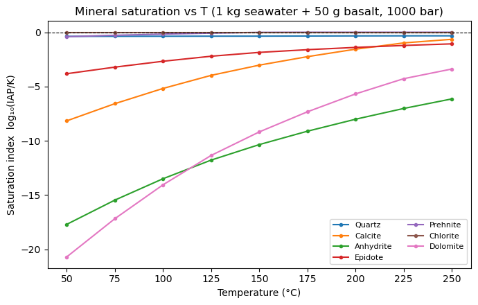

```python
# a modest reacted mix: 1 kg seawater + 50 g basalt glass
mix_b = seawater+basalt.scale_to_mass(0.050)

track = ["Quartz", "Calcite", "Anhydrite", "Epidote", "Prehnite", "Chlorite", "Dolomite"]  # EDIT to your DB
temps_C = np.arange(50, 251, 25)
P_fixed = 1000e5

rows = []
for tC in temps_C:
    gems.equilibrate(tC + 273.15, P_fixed, mix_b)
    si = gems.phase_sat_indices
    rows.append({m: si.get(m, np.nan) for m in track})
si_T = pd.DataFrame(rows, index=temps_C)
si_T.index.name = "T_degC"

# ploting
plt.figure(figsize=(7, 4.5))
for m in track:
    #if si_T[m].notna().any():
    plt.plot(si_T.index, si_T[m], marker="o", ms=3, label=m)
plt.axhline(0, color="k", lw=0.8, ls="--")
plt.xlabel("Temperature (°C)"); plt.ylabel("Saturation index  log₁₀(IAP/K)")
plt.title("Mineral saturation vs T (1 kg seawater + 50 g basalt, 1000 bar)")
plt.legend(fontsize=8, ncol=2); plt.tight_layout(); plt.show()
```

### 8b. Eh–pH of the reacting fluid along the same T ramp

A compact redox/acidity trajectory — where does basalt–seawater interaction drive the fluid on the Eh–pH plane as it heats up?

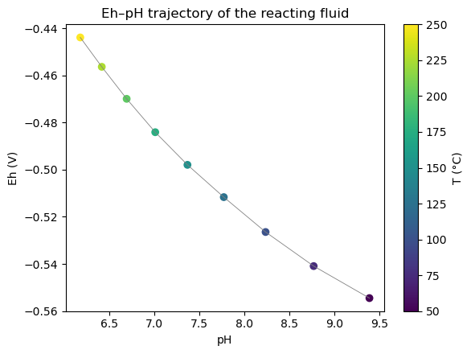

```python
eh, ph = [], []
for tC in temps_C:
    gems.equilibrate(tC + 273.15, P_fixed, mix_b)
    eh.append(gems.Eh); ph.append(gems.pH)

plt.figure(figsize=(6, 4.5))
sc = plt.scatter(ph, eh, c=temps_C, cmap="viridis")
plt.plot(ph, eh, lw=0.6, color="grey")
plt.colorbar(sc, label="T (°C)")
plt.xlabel("pH"); plt.ylabel("Eh (V)")
plt.title("Eh–pH trajectory of the reacting fluid")
plt.tight_layout(); plt.show()
```

### 8c. Dominant aqueous speciation of a chosen element

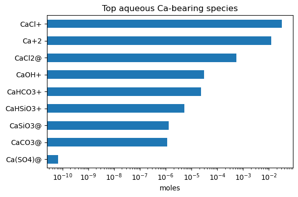

```
CaCl+       3.139956e-02
Ca+2        1.248792e-02
CaCl2@      5.378580e-04
CaOH+       3.094315e-05
CaHCO3+     2.342824e-05
CaHSiO3+    5.180705e-06
CaSiO3@     1.318355e-06
CaCO3@      1.159856e-06
Ca(SO4)@    6.632886e-11
dtype: float64
```

```python
gems.equilibrate(250 + 273.15, P_fixed, mix_b)

element_of_interest = "Ca"
sp_moles   = gems.species_moles
sp_charges = gems.species_charges
aq_phase = gems.aq_phase_symbol

aq_species = gems.species_in_phase[aq_phase]

# keep species whose formula/name contains the letter symbol
# more complex search is needed for elements like C that will have false positives (e.g., "Cl" for chlorine, "C" for carbon)
ca_sp = {sp: sp_moles[sp] for sp in aq_species
             if element_of_interest in sp and sp_moles[sp] > 0}
ser = pd.Series(ca_sp).sort_values(ascending=False).head(10)

plt.figure(figsize=(6, 4))
ser.iloc[::-1].plot(kind="barh")
plt.xscale("log"); plt.xlabel("moles"); plt.title(f"Top aqueous {element_of_interest}-bearing species")
plt.tight_layout(); plt.show()
ser
```

*End of tutorial 1.* Tutorial 2 uses these same `Material` builds to run a basalt→seawater titration at 250 °C / 1000 bar and plot phase volumes.